# Project Report: Evolutionary Approach to Sentiment Analysis on Social Media Data

Author: Sachin Basyal

Date: January 2026

Tools Used: Python, Scikit-Learn, XGBoost, LightGBM, MLflow, DagsHub, Optuna

## I. Executive Summary

This research project focused on building a robust Sentiment Analysis classifier for social media comments (Reddit/YouTube). The primary objective was to accurately classify comments into Positive, Neutral, and Negative categories, with a specific focus on overcoming the challenges of class imbalance and noisy unstructured text.

Through a series of six controlled experiments, we evolved our approach from a baseline Random Forest model (Accuracy: ~66%) to a sophisticated Stacking Ensemble (Accuracy: ~86%). This report documents the experimental methodology, the "failures" that led to deeper insights, and the final architectural decisions.

## II. Table of Contents

- Exploratory Data Analysis (EDA)
- Experiment 01 & 02: Baseline Modeling & Text Representation
- Experiment 03: Feature Space Optimization
- Experiment 04: Addressing Class Imbalance
- Experiment 05: Gradient Boosting & Hyperparameter Tuning
- Experiment 06: Stacking Ensemble (The Champion Model)
- Final Conclusion & Future Work

## III. Exploratory Data Analysis (EDA)

Objective: To understand the distribution, quality, and linguistic characteristics of the dataset before modeling.

**Key Findings:**

Class Imbalance: The dataset was heavily skewed. Positive and Neutral comments dominated, while Negative comments (Class -1) were significantly underrepresented. This posed an early risk of the model biasing toward the majority classes.

Text Noise: Raw data contained significant noise, including emojis, URLs, and slang. We implemented a cleaning pipeline to normalize text (lowercase, punctuation removal) while preserving semantic meaning.

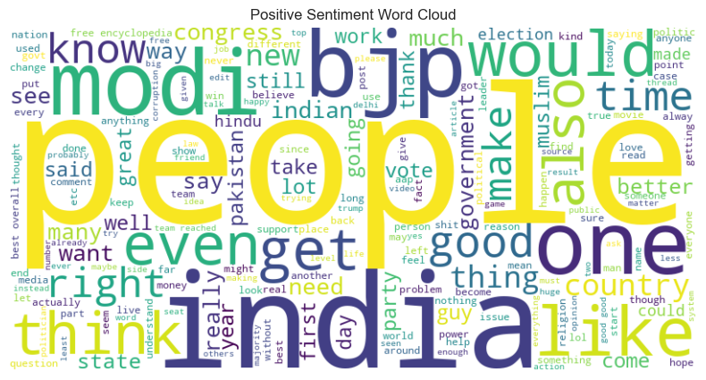

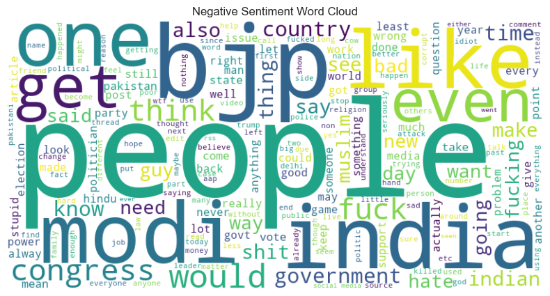

## IV. Experiment 01 & 02: Baseline Modeling & Text Representation

**Hypothesis:** A simple Bag-of-Words approach with a Random Forest classifier will serve as a sufficient baseline.

Methodology: We compared Unigrams (single words) vs. Bigrams (word pairs) vs. Trigrams. We utilized a Random Forest Classifier for its interpretability and resistance to overfitting.

[figure not shown]

**Results:**

Unigrams: Failed to capture context (e.g., "not good" was treated as "not" and "good").

Performance Ceiling: The baseline model achieved approximately 66% Accuracy.

**Conclusion:** While Bigrams provided the best text representation, the Random Forest model hit a "performance wall." It struggled to distinguish subtle negative sentiments, likely due to the class imbalance identified in EDA.

## V. Experiment 03: Feature Space Optimization

**Objective:** To determine the optimal vocabulary size (max_features) for the TF-IDF vectorizer.

**Methodology:** We ran an optimization loop testing vocabulary sizes ranging from 1,000 to 10,000 features. We tracked the trade-off between Accuracy and Computational Cost using MLflow.

[figure not shown]

**Observation:** Surprisingly, increasing the feature size did not linearly improve performance. The model reached an "elbow point" at 1,000 features, where adding more rare words introduced noise (sparsity) rather than signal.

**Decision:** We standardized on 1,000 features for the intermediate experiments to maintain training speed, though we noted that advanced models (like Linear Regressors) might benefit from larger feature spaces later.

## VI. Experiment 04: Addressing Class Imbalance

**Problem:** The model was consistently misclassifying Negative comments as Neutral. Recall for the Negative class was unacceptably low (~0.04).

**Class Weights:** Penalizing the model for missing negative cases (Result: Moderate improvement).

**SMOTE (Synthetic Minority Over-sampling Technique):** Synthetically generating new examples of Negative comments.

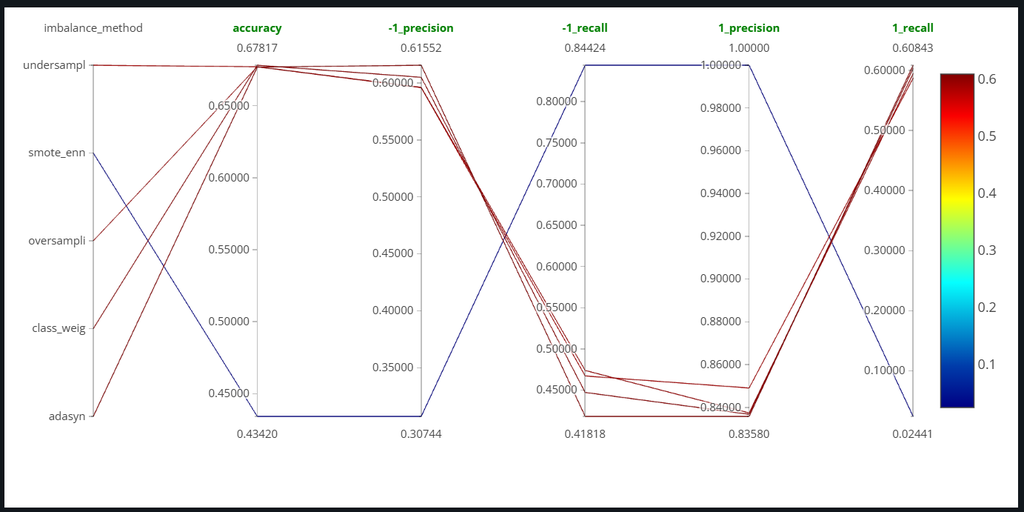

## VII. Experiment 05: Gradient Boosting & Hyperparameter Tuning

**Hypothesis:** Tree-based bagging (Random Forest) is too "shallow" for this task. Gradient Boosting (XGBoost), which learns sequentially from errors, will extract more signal.

**Methodology:**

- Algorithm: XGBoost (Extreme Gradient Boosting).
- Optimization: We employed Optuna (Bayesian Optimization) with Stratified K-Fold Cross-Validation to tune learning rate, tree depth, and estimators.
- Correction: During this phase, we identified and fixed a critical data pipeline bug where the Negative class mapping {-1: 2} was dropping rows.

[figure not shown]

**Results:**

- Baseline (RF): ~66.0%
- XGBoost (Tuned): 77.47%

## VIII. Experiment 06: Stacking Ensemble (The Champion Model)

**Hypothesis:** A single model has biases. Combining a Linear Model (good at high-dimensional text) with a Non-Linear Tree Model (good at interactions) will yield superior results.

**Methodology:** We constructed a Stacking Classifier:

- Base Learner 1: Logistic Regression (Linear) – effective on sparse TF-IDF matrices.
- Learner 2: LightGBM (Gradient Boosting) – effective on complex patterns.
- Meta Learner: K-Nearest Neighbors (KNN) – combines predictions based on proximity.
- Feature Expansion: We increased TF-IDF features to 10,000 with Trigrams, hypothesizing that the Logistic Regression component could handle the sparsity better than trees alone.

**Classification Report:**

Stacking Complete. Accuracy: 0.8597 precision recall f1-score support

```
       0       0.86      0.94      0.90      2529
       1       0.88      0.86      0.87      3154
       2       0.81      0.73      0.77      1650

accuracy                           0.86      7333
macro avg      0.85      0.84      0.85      7333
weighted avg   0.86      0.86      0.86      7333
```

🏃 View run Stacking_LGBM_LogReg_KNN at: https://dagshub.com/frivorocker/yt_baseline_model.mlflow/#/experiments/6/runs/ff987ac46b124062a32c7245e7108e28

🧪 View experiment at: https://dagshub.com/frivorocker/yt_baseline_model.mlflow/#/experiments/6

**Final Results:**

- XGBoost (Exp 05): **77.5%**
- Stacking Ensemble: **86%**

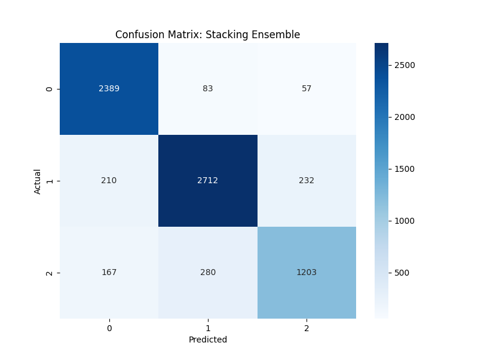

**Conclusion:** This architecture achieved our highest accuracy to date. The combination of linear and tree-based decision boundaries allowed the model to capture both simple keyword associations (e.g., "bad" = Negative) and complex contextual sarcasm.

## IX. Final Conclusion & Future Work

**Final Metrics (Test Set):**

- Accuracy: 86%
- Precision (Weighted): 0.86
- Recall (Weighted): 0.86

**Capabilities Demonstrated**

- MLops: utilized MLflow and DagsHub for experiment tracking and reproducibility.
- Data Engineering: Built robust pipelines to handle parsing errors, label mapping, and vectorization.
- Advanced Modeling: Implemented state-of-the-art Ensemble techniques (Stacking) and Bayesian Optimization (Optuna).

**Future Work**

To further elevate this project from a research prototype to a production system, the following steps are proposed:

1. Deep Learning Integration: Explore Transformer-based architectures (BERT/RoBERTa) to capture deep semantic context and bidirectional dependencies that TF-IDF vectors may miss.
2. Advanced MLOps Pipeline: Integrate DVC (Data Version Control) to build end-to-end **MLOps pipelines**. This will ensure that large datasets are versioned alongside code, creating a fully reproducible training lineage.
3. Real-Time Deployment: Develop a **Google Chrome Plugin** that utilizes our champion Stacking Model to perform **real-time sentiment analysis on YouTube Live Comments**, providing content creators with instant, actionable feedback on audience engagement.